# 103.5. Image display with matplotlib

For the Rubin Science Platform at data.lsst.cloud.  
Data Release: [Data Preview 2](https://dp2.lsst.io/)  
Container Size: Large  
LSST Science Pipelines version: r30.0.10  
Last verified to run: 2026-07-24  
Repository: github.com/lsst/tutorial-notebooks  
DOI: 10.11578/rubin/dc.20250909.20

**Learning objective:** How to use `matplotlib` as a backend for `afwDisplay`.

**LSST data products:** `deep_coadd`

**Packages:** `lsst.daf.butler`, `lsst.afw.display`, `astropy.coordinates`

**Credit:** Originally developed by the Rubin Community Science team. Please consider acknowledging them if this notebook is used for the preparation of journal articles, software releases, or other notebooks.

**Get Support:** Everyone is encouraged to ask questions or raise issues in the [Support Category](https://community.lsst.org/c/support) of the Rubin Community Forum. Rubin staff will respond to all questions posted there.

## 1. Introduction

This is a tutorial for displaying images with `lsst.afw.display` and `matplotlib`.

**Firefly is the recommended backend** for displaying LSST images, and is covered by another tutorial in this series.

**Caveats.** This tutorial demonstrates a pitfall of using `matplotlib`: the use of `extent` with `imshow` is necessary, because the pixel origin is not 1,1 for a `deep_coadd`. This is one of the reasons why `matplotlib` is not the recommended backend for image display; see the related Firefly tutorial for the recommended approach.

**For Early Data Preview 2**, this notebook covers `deep_coadd` display only, and `visit_image` support will be added once visit-level images become available in DP2.

**Related tutorials**: The 100-level series on the Butler demonstrates how to find and retrieve images, and the image display with Firefly tutorial.

### 1.1. Import packages

Import the `Butler` module from the `lsst.daf.butler` package, the `display` module from the `lsst.afw` package (for image display), the `SkyCoord` class from `astropy.coordinates` and the `astropy.units` module (for converting sky coordinates to pixel positions), the `matplotlib.pyplot` sublibrary for plotting, the general package `numpy` for analysis, and the `gc` (garbage collector) package to help clear the memory of large plots.

```python
from lsst.daf.butler import Butler
import lsst.afw.display as afw_display
from lsst.images import get_legacy_deep_coadd_mask_planes
from astropy.coordinates import SkyCoord
import astropy.units as u
import matplotlib.pyplot as plt
import numpy as np
import gc
```

### 1.2. Define parameters and functions

#### 1.2.1. Functions

`matplotlib` stores the data array associated with an image that is plotted. Since the LSST Charge-Coupled Device (CCD) detector images are large (~4k x 4k pixels), this can eventually lead to a memory overflow, which will cause the notebook kernel to die. To mitigate this issue, define a function to clean up after plotting them.

```python
def remove_figure(fig):
    """
    Remove a figure to reduce memory footprint.

    Parameters
    ----------
    fig: matplotlib.figure.Figure
        Figure to be removed.

    Returns
    -------
    None
    """

    for ax in fig.get_axes():
        for im in ax.get_images():
            im.remove()

    fig.clf()
    plt.close(fig)
    gc.collect()
```

Define a function to draw a compass, showing the directions of North (N) and East (E), centered on the search location. The $cos(\rm{dec})$ term is included in the length of the compass arm for "East".

```python
def draw_compass(ax, wcs, ra, dec, clen, x0=0, y0=0):
    """
    Draw a compass, showing the directions of North (N) and East (E),
      centered on the search location.

    Parameters
    ----------
    ax: matplotlib.axes._axes.Axes
        Axes for showing a plot.
    wcs: astropy.wcs.WCS
        WCS of an image.
    ra: float
        RA of a celestial location in degree.
    dec: float
        DEC of a celestial location in degree.
    clen: float
        Compass arm length in arcseconds.
    x0: float
        Pixel offset added to the WCS pixel coordinates, since
        world_to_pixel() returns coordinates local to the WCS rather
        than the bbox-based extent used to display the image.
    y0: float
        Pixel offset added to the WCS pixel coordinates, same as x0.

    Returns
    -------
    None
    """

    cosdec = np.cos(np.deg2rad(dec))
    x, y = wcs.world_to_pixel(SkyCoord(ra * u.deg, dec * u.deg))
    xN, yN = wcs.world_to_pixel(SkyCoord(ra * u.deg, (dec + clen / 3600.) * u.deg))
    xE, yE = wcs.world_to_pixel(SkyCoord((ra + (clen / 3600.) / cosdec) * u.deg, dec * u.deg))
    x, y = x + x0, y + y0
    xN, yN = xN + x0, yN + y0
    xE, yE = xE + x0, yE + y0
    ax.annotate('', xy=(xN, yN), xytext=(x, y),
                arrowprops=dict(color='yellow', linewidth=2, arrowstyle='->'))
    ax.text(xN, yN, 'N', color='yellow', fontsize=14)
    ax.annotate('', xy=(xE, yE), xytext=(x, y),
                arrowprops=dict(color='cyan', linewidth=2, arrowstyle='->'))
    ax.text(xE, yE, 'E', color='cyan', fontsize=14)
```

Define a function to zoom in on the search location.

```python
def zoom_in(ax, wcs, ra, dec, side, x0=0, y0=0):
    """
    Zoom in on the search location.

    Parameters
    ----------
    ax: matplotlib.axes._axes.Axes
        Axes for showing a plot.
    wcs: astropy.wcs.WCS
        WCS of an image.
    ra: float
        RA of a celestial location in degree.
    dec: float
        DEC of a celestial location in degree.
    side: float
        Size of the display region in arcseconds.
    x0: float
        Pixel offset added to the WCS pixel coordinates, since
        world_to_pixel() returns coordinates local to the WCS rather
        than the bbox-based extent used to display the image.
    y0: float
        Pixel offset added to the WCS pixel coordinates, same as x0.

    Returns
    -------
    None
    """

    x, y = wcs.world_to_pixel(SkyCoord(ra * u.deg, dec * u.deg))
    x, y = x + x0, y + y0
    pixel_scale = 0.2
    side_pix = side / pixel_scale
    ax.set_xlim([x - side_pix / 2, x + side_pix / 2])
    ax.set_ylim([y - side_pix / 2, y + side_pix / 2])
```

#### 1.2.2. Parameters

Set `afwDisplay` to use `matplotlib`.

```python
afw_display.setDefaultBackend("matplotlib")
```

Instantiate the butler.

```python
butler = Butler.from_config('dp2', collections='dp2')
```

## 2. Display an image with lsst.afw.display

Define an RA, Dec, and band (filter). These coordinates are near the center of the Extended Chandra Deep Field South (ECDFS).

```python
ra = 53.076
dec = -28.110
band = 'r'
```

Define a query string using the coordinates and band as search constraints. Query the butler for matching `deep_coadd` images and retrieve the first on the list. Apply the `'pretty'` background, which is tuned for visualization, since the raw pixel values otherwise still include an unsubtracted sky background.

```python
query = "band.name = :band AND patch.region OVERLAPS POINT(:ra, :dec)"
bind = {'band': band, 'ra': ra, 'dec': dec}
deep_coadd_refs = butler.query_datasets("deep_coadd", where=query,
                                        bind=bind, order_by='patch')
deep_coadd = butler.get(deep_coadd_refs[0])
deep_coadd.apply_background('pretty')
```

Display the retrieved image in `matplotlib`. Define `afw_display` to show images. Recommend to set the scale to `linear` stretch and use the automatic algorithm `zscale` to select the white and black thresholds. Remove the underlying data from memory after creating and displaying the image.

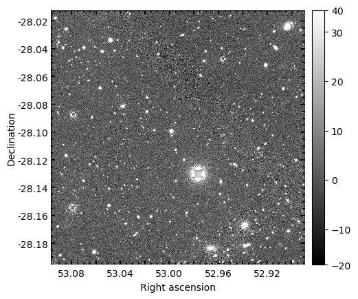

```python
fig, ax = plt.subplots()
display = afw_display.Display(frame=fig)
display.scale('linear', 'zscale')
display.image(deep_coadd.image)
plt.show()
remove_figure(fig)
```

> Figure 1: A `deep_coadd` with the `linear` and `zscale` scaling and without the mask overlay, displayed in grayscale with a scale bar at right.

Option to read the API documentation about the above functions using the Jupyter notebook `help()` function.

```python
# help(display.scale)
```

```python
# help(display.image)
```

### 2.1. Scaling options

There are other options for scaling. Show the same image using the `asinh` and `zscale` scaling, and `linear` with explicit minimum and maximum values. Using `plt.tight_layout()` with multi-axis figures helps to avoid axis overlap or excessive white spaces and results in a nicer-looking plot.

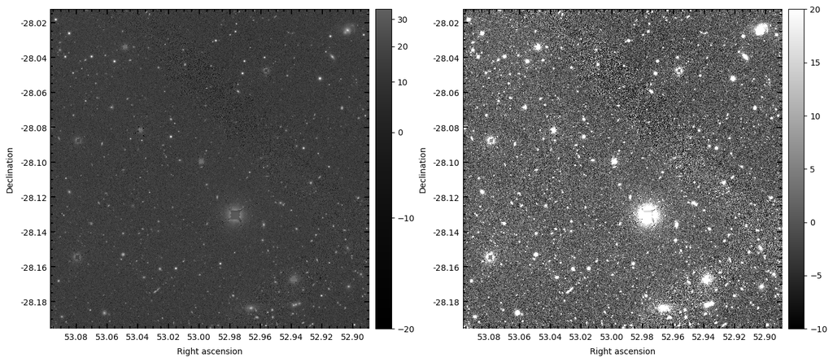

```python
fig, ax = plt.subplots(1, 2, figsize=(14, 7))
plt.sca(ax[0])
display1 = afw_display.Display(frame=fig)
display1.scale('asinh', 'zscale')
display1.image(deep_coadd.image)
plt.sca(ax[1])
display2 = afw_display.Display(frame=fig)
display2.scale('linear', min=-10., max=20)
display2.image(deep_coadd.image)
plt.tight_layout()
plt.show()
remove_figure(fig)
```

> Figure 2: Left: The same `deep_coadd` with the `asinh` and `zscale` scaling. Right: The `linear` scaling with explicit minimum and maximum values.

### 2.2. Manipulate the mask display

Each image returned by the butler contains more than just the image pixel values. One other component is the mask associated with the image. A mask is composed of a set of "mask planes", 2D binary bit maps corresponding to pixels that are masked for various reasons.

The display framework renders each plane (each bit) of the mask in a different color. View the mapping between the mask plane and the color using the following code.

> **Notice:** One of the changes with DP2's new image types is more informative mask names. However, the old mask names and colors are still being used by `afw.display`. The following is a temporary workaround to print new names with the colors defined by `display`. Once this is fixed, mask plane definitions will be able to be printed with `print("Mask plane bit definitions:\n", display1.getMaskPlaneColor())`.

```python
mask = deep_coadd.mask
new_to_old_convert = {v.name: k for k, v in get_legacy_deep_coadd_mask_planes().items()}
for new_name in mask.schema.names:
    print('{} {}'.format(new_name,
                         display1.getMaskPlaneColor(new_to_old_convert[new_name])))
```

```
NO_DATA orange
INTERPOLATED green
COSMIC_RAY magenta
SATURATED green
DETECTION_EDGE yellow
CLIPPED None
REJECTED None
DETECTED blue
INEXACT_PSF None
```

Plot the image and mask plane side-by-side using `matplotlib` subplots.

Use `plt.sca(ax[0])` to set the first axis as current, and then `plt.sca(ax[1])` to switch to the second axis.

Plot the `deep_coadd`.

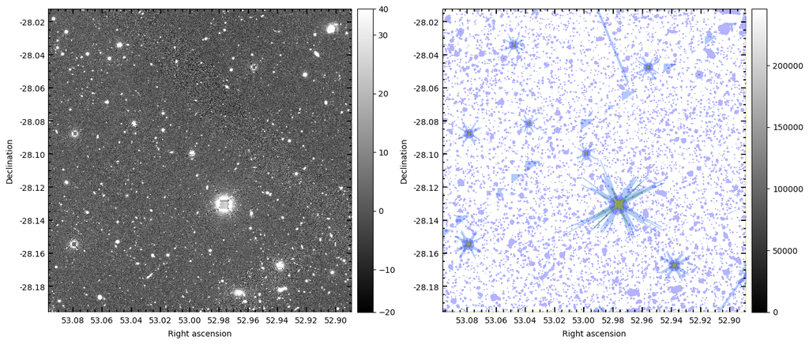

```python
fig, ax = plt.subplots(1, 2, figsize=(14, 7))
plt.sca(ax[0])
display1 = afw_display.Display(frame=fig)
display1.scale('linear', 'zscale')
display1.image(deep_coadd.image)
plt.sca(ax[1])
display2 = afw_display.Display(frame=fig)
display2.image(deep_coadd.mask)
plt.tight_layout()
plt.show()
remove_figure(fig)
```

> Figure 3: At left, the same `deep_coadd`. At right, the mask plane for the `deep_coadd` illustrates which pixels have a mask value.

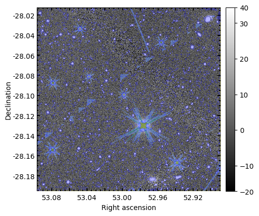

```python
fig, ax = plt.subplots()
display = afw_display.Display(frame=fig)
display.scale('linear', 'zscale')
display.image(deep_coadd)
plt.show()
remove_figure(fig)
```

> Figure 4: The `deep_coadd` with the mask plane overlaid.

To investigate the mask in a bit more detail, follow the same steps as above to display the image, but add a few modifications. Set the transparency of the overplotted mask to 10% (0 = opaque, 100 = transparent). Change the color of the 'DETECTED' mask plane from 'blue' (as above) to 'green' (i.e., all pixels associated with detected objects). Pass the full image object to `display.image()` instead of just the image plane.

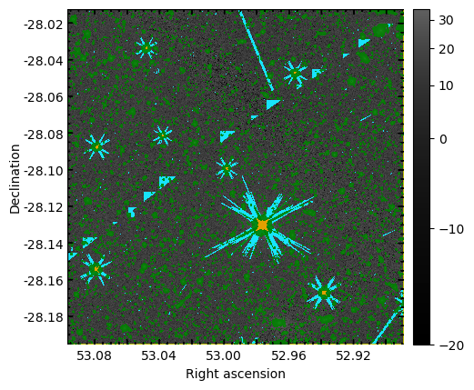

```python
fig, ax = plt.subplots()
display = afw_display.Display(frame=fig)
display.scale('asinh', 'zscale')
display.setMaskTransparency(10)
display.setMaskPlaneColor('DETECTED', 'green')
display.image(deep_coadd)
plt.show()
remove_figure(fig)
```

> Figure 5: Similar to the previous figure of `deep_coadd`, but with the mask transparency reduced to 10% (mostly opaque), and the color representing 'DETECTED' pixels changed from blue to green.

### 2.3. Plot markers

In general the Table Access Protocol（TAP）service is the recommended access mechanism for catalog data.

However, in the case where all the objects detected in a given `deep_coadd` are desired, the Butler offers a quick way to retrieve them.

Use the `dataId` for the `deep_coadd` image to retrieve the `object` table for the `tract`.

```python
dataId = deep_coadd_refs[0].dataId
```

Retrieve the `patch`, the objects' r-band sky coordinates, and the r-band Point Spread Function (PSF) flux (with uncertainty). The `object` table stores position as `r_ra`/`r_dec` rather than pixel coordinates, so these are converted to pixel positions using the `deep_coadd` WCS before plotting.

```python
use_columns = ['objectId', 'patch',
               'r_ra', 'r_dec',
               'r_psfFlux', 'r_psfFluxErr']
objects = butler.get('object', tract=dataId.get('tract'),
                     parameters={'columns': use_columns})
```

Identify objects in the patch of the displayed `deep_coadd` image.

```python
tx = np.where(objects['patch'] == dataId.get('patch'))[0]
print("Number of objects: ", len(tx))
```

```
Number of objects:  9058
```

Since there are many objects, filter objects by their Signal-to-Noise ratio (S/N) to make the following scatter plot more clear.

```python
sel = objects['r_psfFlux'] / objects['r_psfFluxErr'] > 300
objects = objects[sel]
tx = np.where(objects['patch'] == dataId.get('patch'))[0]
print("Number of objects: ", len(tx))
```

```
Number of objects:  138
```

Redisplay the `deep_coadd` with no mask. Use buffering to display orange circles at the location of every object (this avoids re-drawing the image after each object is plotted.).

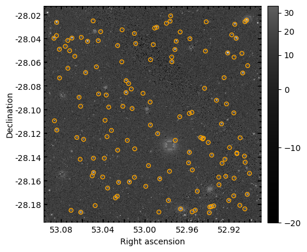

```python
fig, ax = plt.subplots()
afw_display = afw_display.Display(frame=fig)
afw_display.scale('asinh', 'zscale')
afw_display.setMaskTransparency(100)
afw_display.image(deep_coadd.image)
with afw_display.Buffering():
    for i in tx:
        sky_point = SkyCoord(objects[i]['r_ra'] * u.deg, objects[i]['r_dec'] * u.deg)
        pix = deep_coadd.sky_projection.sky_to_pixel(sky_point)
        afw_display.dot('o', pix.x, pix.y, size=30, ctype='orange')
plt.show()
remove_figure(fig)
```

> Figure 6: The same `deep_coadd`, but with orange circles marking the location of `objects` that have high S/N.

**Why are no objects near the edges marked?**

The `deep_coadd` images are per-patch, and patches and `deep_coadd` images overlap at their edges. The `object` table is by `tract`, and has no duplicates -- there is only one row per detected object. For every object the `patch` column is the patch for which they are closest to the center. The stars and galaxies near the edges of the displayed `deep_coadd` image are listed as belonging to the adjacent patch.

## 3. Display an image with `imshow`

In order to display the image axes in sky coordinates, use `matplotlib.pyplot`'s `subplot`, `imshow`, and `grid` functions, along with `astropy`'s WCS package.

### 3.1. Display the `deep_coadd`

The `extent` parameter in `imshow` defines the bounding box for the image to show. Define the `extent` using the boundary of `BBox`.

```python
deep_coadd_extent = (deep_coadd.bbox.x.start, deep_coadd.bbox.x.stop,
                     deep_coadd.bbox.y.start, deep_coadd.bbox.y.stop)
```

Check the `extent`. Note the use of `extent` with `imshow` is necessary, because the pixel origin is not 1,1 for the `deep_coadd`.

```python
print("Extent (xmin, xmax, ymin, ymax): ", deep_coadd_extent)
print("Number of rows and columns of the image array: ", np.shape(deep_coadd.image.array))
```

```
Extent (xmin, xmax, ymin, ymax):  (14850, 18150, 2850, 6150)
Number of rows and columns of the image array:  (3300, 3300)
```

Set the figure's projection to be the WCS of the image. Define the extent in pixel coordinates using the bounding box. Display the image data array using the gray colormap (`cmap`). Add solid white grid lines. Label the axes, and show the plot. Remove the underlying data from memory.

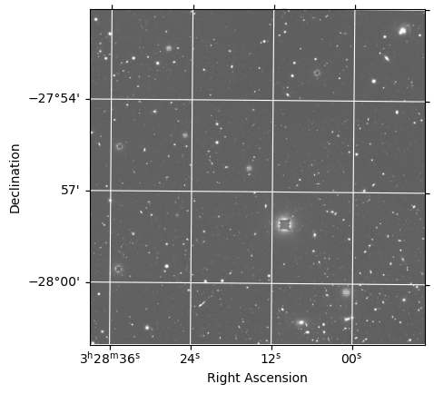

```python
fig = plt.figure()
plt.subplot(projection=deep_coadd.fits_wcs)
im = plt.imshow(deep_coadd.image.array, cmap='gray',
                vmin=-75, vmax=125,
                extent=deep_coadd_extent,
                origin='lower')
plt.grid(color='white', ls='solid')
plt.xlabel('Right Ascension')
plt.ylabel('Declination')
plt.show()
remove_figure(fig)
```

> Figure 7: The same `deep_coadd` displayed with the `gray` colormap at minimum -75 and maximum 125. Axes label and grid are in world coordinates. Notice that RA is in h:m:s, not degrees as in previous figures, when the `fits_wcs` is used for the sky projection.

### 3.2. Compass and zoom-in

Plot the image again. Show a compass (the arm length is 50 arcseconds) in one panel, and a zoom-in case (the box side is 140 arcseconds) in another panel.

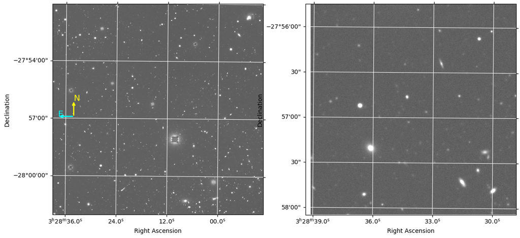

```python
fig, (ax1, ax2) = plt.subplots(1, 2, figsize=(14, 7),
                               subplot_kw={'projection': deep_coadd.astropy_wcs})
for ax in [ax1, ax2]:
    im = ax.imshow(deep_coadd.image.array, cmap='gray',
                   vmin=-75, vmax=125,
                   extent=deep_coadd_extent,
                   origin='lower')
    ax.coords[0].set_major_formatter('hh:mm:ss.s')
    ax.coords[1].set_major_formatter('dd:mm:ss')
    ax.grid(color='white', ls='solid')
    ax.set_xlabel('Right Ascension')
    ax.set_ylabel('Declination')
x0 = deep_coadd.bbox.x.start
y0 = deep_coadd.bbox.y.start
clen = 50
draw_compass(ax1, deep_coadd.astropy_wcs, ra, dec, clen, x0=x0, y0=y0)
side = 140
zoom_in(ax2, deep_coadd.astropy_wcs, ra, dec, side, x0=x0, y0=y0)
plt.show()
remove_figure(fig)
```

> Figure 8: The same `deep_coadd` displayed with the `gray` colormap at minimum -75 and maximum 125. Axes label and grid are in world coordinates. At left, the full `deep_coadd` with a compass. At right, a zoom-in of the `deep_coadd` on the search location.

### 3.3. Plot markers

Plot markers onto an image displayed with `imshow`. Repeat the previous to display the `deep_coadd` with `matplotlib`, and use a scatter plot to show `objects`.

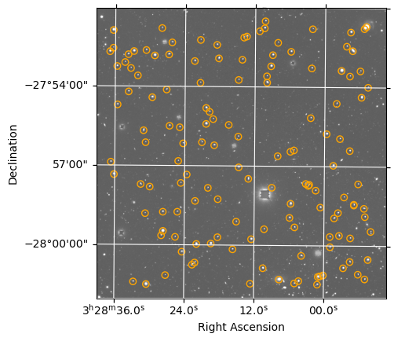

```python
fig = plt.figure()
ax = fig.add_subplot(111, projection=deep_coadd.astropy_wcs)
im = ax.imshow(deep_coadd.image.array, cmap='gray',
               vmin=-75, vmax=125,
               extent=deep_coadd_extent,
               origin='lower')
sky_points = SkyCoord(objects[tx]['r_ra'] * u.deg, objects[tx]['r_dec'] * u.deg)
pix_x, pix_y = deep_coadd.astropy_wcs.world_to_pixel(sky_points)
pix_x = pix_x + deep_coadd.bbox.x.start
pix_y = pix_y + deep_coadd.bbox.y.start
ax.scatter(pix_x, pix_y, facecolors='none', edgecolors='orange')
ax.coords[0].set_major_formatter('hh:mm:ss.s')
ax.coords[1].set_major_formatter('dd:mm:ss')
ax.set_xlabel('Right Ascension')
ax.set_ylabel('Declination')
ax.grid(color='white', ls='solid')
plt.show()
remove_figure(fig)
```

> Figure 9: The `deep_coadd`, with orange circles marking the location of `objects` that have high S/N.